# Tugas Pertemuan 4

Rai Kazan

2026-09-17

# Proses MA(2)

## Pembangkitan MA(2) secara Manual

```r
set.seed(2406)
wn <- rnorm(300)

ma <- wn[1]
ma[2] <- wn[2] + 0.4 * wn[1]

for(i in 3:300) {
  ma[i] <- wn[i] + 0.4 * wn[i-1] + 0.6 * wn[i-2]
}
ma
```

```
##   [1]  0.065452712 -2.131688032 -0.957459575 -1.997684110  0.856531084
##   [6] -0.090718002 -1.232925526 -0.763383925 -1.139789587  0.768529557
##  [11]  0.087839148 -0.619444855  0.074439630  1.074942733  2.453386978
##  [16]  1.464292087 -0.208508483  0.056338990 -1.777543481  0.815122393
##  [21]  0.167158485  1.341613258  1.400652833  0.325586357  1.073234152
##  [26]  0.170879306  0.778291036 -0.248842275 -1.187395089 -1.799528186
##  [31] -3.120091603 -1.795568401 -0.339170044  0.814313097  1.387607977
##  [36]  0.190647236 -0.939961007 -1.440418286 -0.370081307  1.510359878
##  [41] -0.096020235  0.655919286 -0.385444921  0.000370164  0.889828430
##  [46]  0.786750666  0.182398659 -0.443150651  1.551465531  0.619953590
##  [51]  1.949480298  1.027936938  0.523664469  1.736981379  2.516473747
##  [56]  3.057017243  1.322542239  1.179666243  0.350605859 -1.123969056
##  [61]  0.286898521 -1.182994721  0.247810680  1.219869937  0.280113017
##  [66]  0.500462720  1.097488510 -1.936980084 -0.968992122 -0.971726010
##  [71]  0.440553201  2.203314346  2.072954956  2.382857818  1.138201607
```

[output cut: 45 more lines]

## Pembangkitan MA(2) dengan arima.sim

```r
ma2 <- arima.sim(list(order = c(0,0,2), ma = c(0.4, 0.6)), n = 300)
ma2
```

```
## Time Series:
## Start = 1
## End = 300
## Frequency = 1
##   [1] -1.8758627655 -0.7345910444 -0.6768116279 -1.1999706611 -0.0509437762
##   [6] -0.9593681923 -0.3970472926  0.4148922431 -0.1332364197  0.2774766244
##  [11] -0.9926333166 -2.1409528180 -0.6800473699 -0.8302733532 -0.6736445626
##  [16]  0.4863428733  0.2212436628  0.8018857631  1.1799035388  2.3897218983
##  [21]  0.8767677448  1.0141584437  0.0036209007  0.2082852318  0.5775908185
##  [26]  0.0260361987  0.7808994852  1.4290391518  0.9224883552  1.8937943829
##  [31]  1.1366652647  1.4685140575  0.3985790243 -0.4233500621  0.4484158771
##  [36] -0.8126956205 -0.1408132717  0.1504484806  0.0700169963  0.8801269535
##  [41]  0.5203669182  0.3754143917 -0.6039482056  0.5810319172  0.1483241807
##  [46]  0.1912359017 -0.2684082883  0.0691131700  0.3404486780  0.1669549983
##  [51]  0.5383774615 -0.0404510598  0.0007660649  0.1570339273 -0.1446354567
```

[output cut: 49 more lines]

## Karakteristik MA(2)

### Plot Time Series

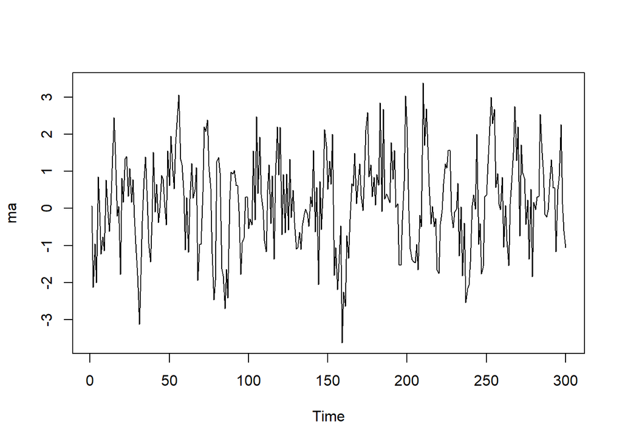

```r
ts.plot(ma)
```

Berdasarkan plot time series, terlihat bahwa data MA(2) yang dibangkitkan stasioner dalam rataan

### Plot ACF

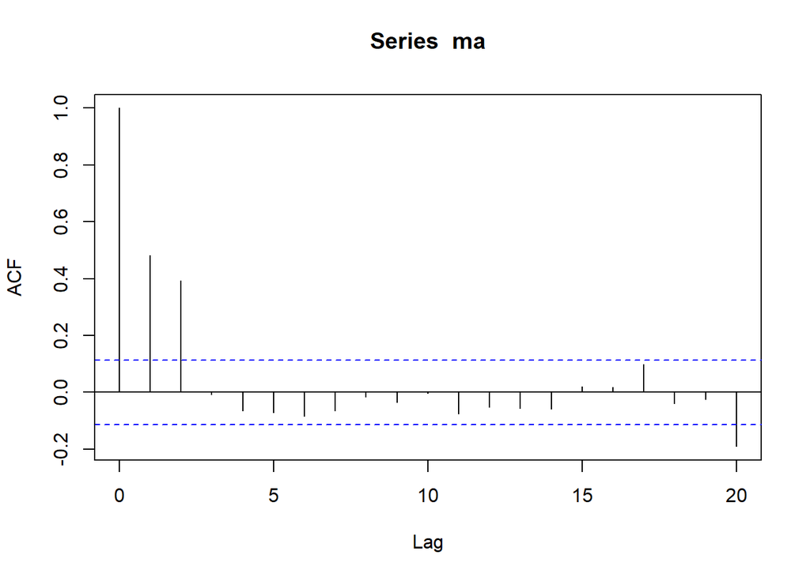

```r
acf(ma, lag.max = 20)
```

Berdasarkan plot ACF tersebut, terlihat bahwa plot ACF cuts off di lag kedua

### Plot PACF

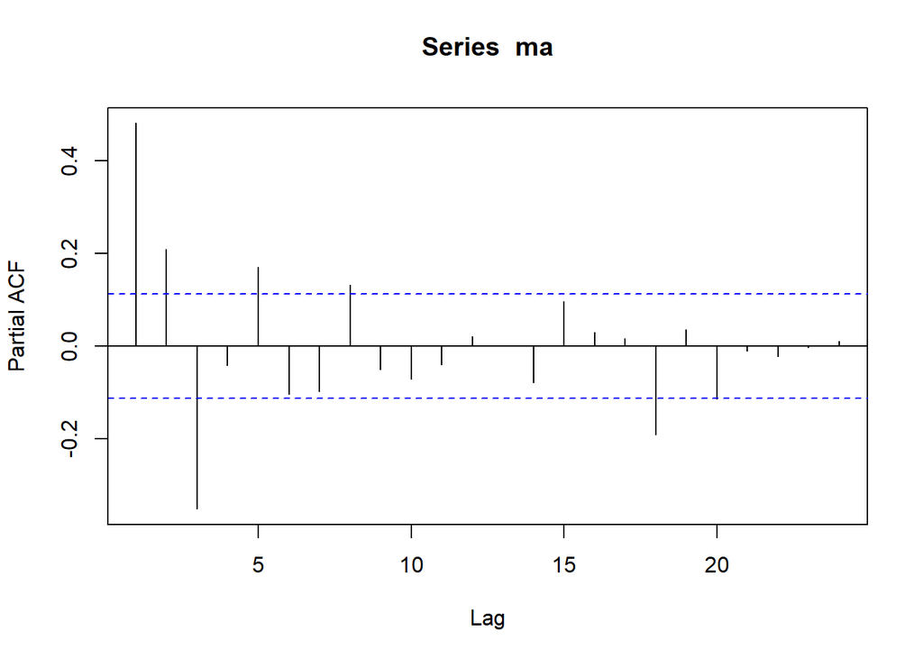

```r
pacf(ma)
```

Berdasarkan plot PACF tersebut, terlihat bahwa plot PACF cenderung tails off dan membentuk gelombang sinus

### Plot EACF

```r
TSA::eacf(ma)
```

```
## AR/MA
##   0 1 2 3 4 5 6 7 8 9 10 11 12 13
## 0 x x o o o o o o o o o  o  o  o
## 1 x x o o o o o o o o o  o  o  o
## 2 x x x o o o o o o o o  o  o  o
## 3 x x x x x o o o o o o  o  o  o
## 4 x x x x o o o o o o o  o  o  o
## 5 x x x x o o x o o o o  o  o  o
## 6 x x x x o o x o o o o  o  o  o
## 7 x x x x o o x o o o o  o  o  o
```

Berdasarkan pola segitiga nol pada plot EACF, terlihat bahwa batas sudut kiri atas segitiga nol berada pada ordo AR(0) dan ordo MA(2)

## Scatterplot Antar Lag

### Korelasi antara $Y_t$ dengan $Y_{t-1}$

```r
#Yt
yt_ma <- ma[-1]
yt_ma
```

```
##   [1] -2.131688032 -0.957459575 -1.997684110  0.856531084 -0.090718002
##   [6] -1.232925526 -0.763383925 -1.139789587  0.768529557  0.087839148
##  [11] -0.619444855  0.074439630  1.074942733  2.453386978  1.464292087
##  [16] -0.208508483  0.056338990 -1.777543481  0.815122393  0.167158485
##  [21]  1.341613258  1.400652833  0.325586357  1.073234152  0.170879306
##  [26]  0.778291036 -0.248842275 -1.187395089 -1.799528186 -3.120091603
##  [31] -1.795568401 -0.339170044  0.814313097  1.387607977  0.190647236
##  [36] -0.939961007 -1.440418286 -0.370081307  1.510359878 -0.096020235
##  [41]  0.655919286 -0.385444921  0.000370164  0.889828430  0.786750666
##  [46]  0.182398659 -0.443150651  1.551465531  0.619953590  1.949480298
##  [51]  1.027936938  0.523664469  1.736981379  2.516473747  3.057017243
##  [56]  1.322542239  1.179666243  0.350605859 -1.123969056  0.286898521
##  [61] -1.182994721  0.247810680  1.219869937  0.280113017  0.500462720
##  [66]  1.097488510 -1.936980084 -0.968992122 -0.971726010  0.440553201
##  [71]  2.203314346  2.072954956  2.382857818  1.138201607  0.541115002
```

[output cut: 45 more lines]

```r
#Yt-1
yt_1_ma <- ma[-300]
yt_1_ma
```

```
##   [1]  0.065452712 -2.131688032 -0.957459575 -1.997684110  0.856531084
##   [6] -0.090718002 -1.232925526 -0.763383925 -1.139789587  0.768529557
##  [11]  0.087839148 -0.619444855  0.074439630  1.074942733  2.453386978
##  [16]  1.464292087 -0.208508483  0.056338990 -1.777543481  0.815122393
##  [21]  0.167158485  1.341613258  1.400652833  0.325586357  1.073234152
##  [26]  0.170879306  0.778291036 -0.248842275 -1.187395089 -1.799528186
##  [31] -3.120091603 -1.795568401 -0.339170044  0.814313097  1.387607977
##  [36]  0.190647236 -0.939961007 -1.440418286 -0.370081307  1.510359878
##  [41] -0.096020235  0.655919286 -0.385444921  0.000370164  0.889828430
##  [46]  0.786750666  0.182398659 -0.443150651  1.551465531  0.619953590
##  [51]  1.949480298  1.027936938  0.523664469  1.736981379  2.516473747
##  [56]  3.057017243  1.322542239  1.179666243  0.350605859 -1.123969056
##  [61]  0.286898521 -1.182994721  0.247810680  1.219869937  0.280113017
##  [66]  0.500462720  1.097488510 -1.936980084 -0.968992122 -0.971726010
##  [71]  0.440553201  2.203314346  2.072954956  2.382857818  1.138201607
```

[output cut: 45 more lines]

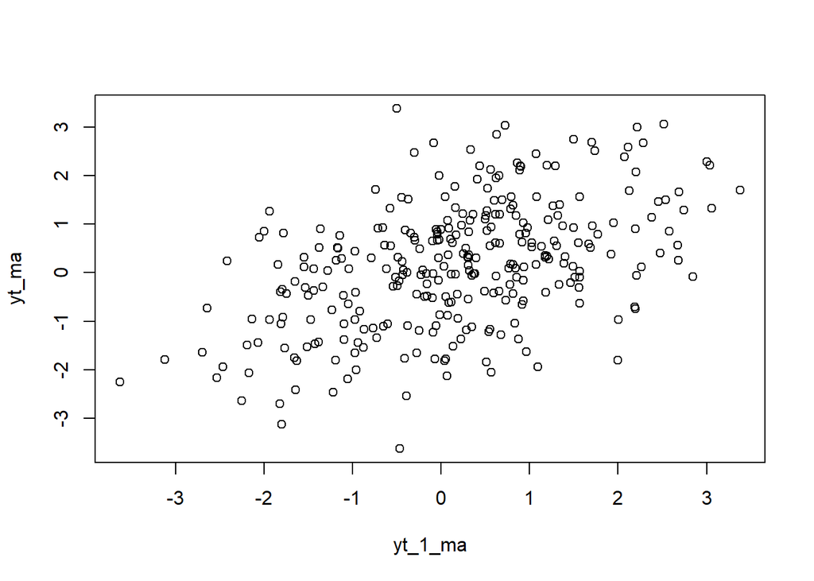

```r
plot(y=yt_ma, x=yt_1_ma)
```

```r
cor(yt_ma, yt_1_ma)
```

```
## [1] 0.4821801
```

Korelasi antara $Y_t$ dengan $Y_{t-1}$ dari hasil simulasi mendekati perhitungan teoritis yaitu
$$\rho_1 =
\frac{\theta_1 + \theta_1\theta_2}{1 + \theta_1^2 + \theta_2^2} =
\frac{0.4 + (0.4)(0.6)}{1 + 0.4^2 + 0.6^2} = 0.421$$

### Korelasi antara $Y_t$ dengan $Y_{t-2}$

```r
#Yt
yt_ma2 <- ma[-c(1,2)]
yt_ma2
```

```
##   [1] -0.957459575 -1.997684110  0.856531084 -0.090718002 -1.232925526
##   [6] -0.763383925 -1.139789587  0.768529557  0.087839148 -0.619444855
##  [11]  0.074439630  1.074942733  2.453386978  1.464292087 -0.208508483
##  [16]  0.056338990 -1.777543481  0.815122393  0.167158485  1.341613258
##  [21]  1.400652833  0.325586357  1.073234152  0.170879306  0.778291036
##  [26] -0.248842275 -1.187395089 -1.799528186 -3.120091603 -1.795568401
##  [31] -0.339170044  0.814313097  1.387607977  0.190647236 -0.939961007
##  [36] -1.440418286 -0.370081307  1.510359878 -0.096020235  0.655919286
##  [41] -0.385444921  0.000370164  0.889828430  0.786750666  0.182398659
##  [46] -0.443150651  1.551465531  0.619953590  1.949480298  1.027936938
##  [51]  0.523664469  1.736981379  2.516473747  3.057017243  1.322542239
##  [56]  1.179666243  0.350605859 -1.123969056  0.286898521 -1.182994721
##  [61]  0.247810680  1.219869937  0.280113017  0.500462720  1.097488510
##  [66] -1.936980084 -0.968992122 -0.971726010  0.440553201  2.203314346
##  [71]  2.072954956  2.382857818  1.138201607  0.541115002 -1.215737523
```

[output cut: 45 more lines]

```r
#Yt-2
yt_2_ma <- ma[-c(299,300)]
yt_2_ma
```

```
##   [1]  0.065452712 -2.131688032 -0.957459575 -1.997684110  0.856531084
##   [6] -0.090718002 -1.232925526 -0.763383925 -1.139789587  0.768529557
##  [11]  0.087839148 -0.619444855  0.074439630  1.074942733  2.453386978
##  [16]  1.464292087 -0.208508483  0.056338990 -1.777543481  0.815122393
##  [21]  0.167158485  1.341613258  1.400652833  0.325586357  1.073234152
##  [26]  0.170879306  0.778291036 -0.248842275 -1.187395089 -1.799528186
##  [31] -3.120091603 -1.795568401 -0.339170044  0.814313097  1.387607977
##  [36]  0.190647236 -0.939961007 -1.440418286 -0.370081307  1.510359878
##  [41] -0.096020235  0.655919286 -0.385444921  0.000370164  0.889828430
##  [46]  0.786750666  0.182398659 -0.443150651  1.551465531  0.619953590
##  [51]  1.949480298  1.027936938  0.523664469  1.736981379  2.516473747
##  [56]  3.057017243  1.322542239  1.179666243  0.350605859 -1.123969056
##  [61]  0.286898521 -1.182994721  0.247810680  1.219869937  0.280113017
##  [66]  0.500462720  1.097488510 -1.936980084 -0.968992122 -0.971726010
##  [71]  0.440553201  2.203314346  2.072954956  2.382857818  1.138201607
```

[output cut: 45 more lines]

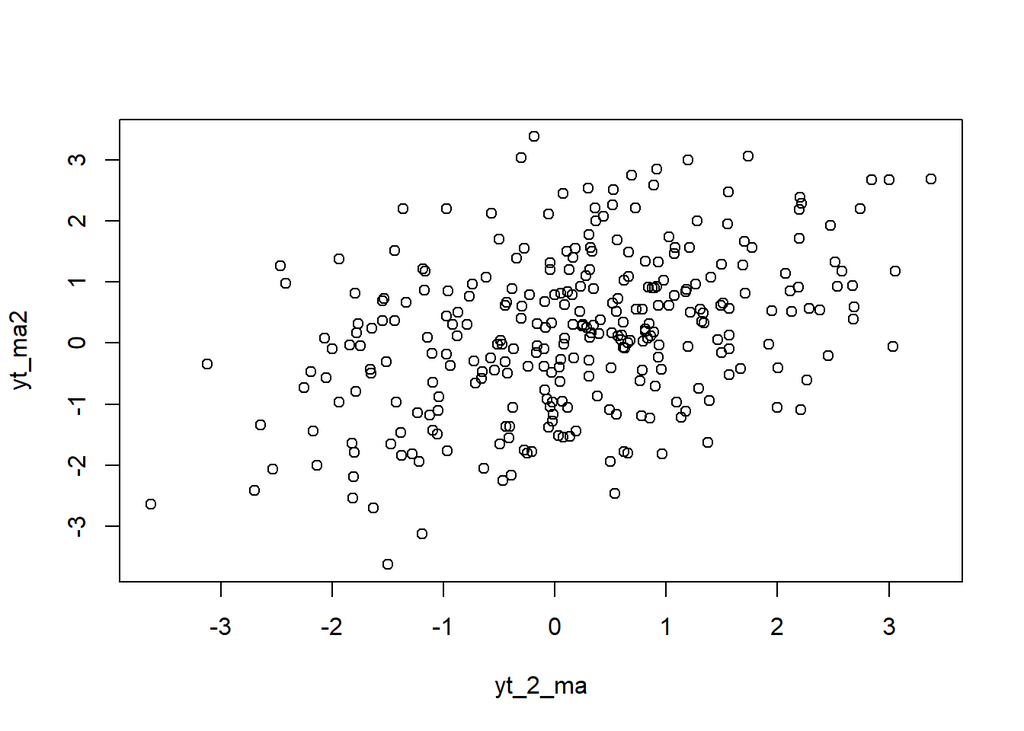

```r
plot(y=yt_ma2, x=yt_2_ma)
```

```r
cor(yt_ma2, yt_2_ma)
```

```
## [1] 0.3954303
```

Korelasi antara $Y_t$ dengan $Y_{t-2}$ dari hasil simulasi mendekati perhitungan teoritis yaitu
$$\rho_2 =
\frac{\theta_2}{1 + \theta_1^2 + \theta_2^2} = \frac{0.6}{1 + 0.4^2 +
0.6^2} = 0.395$$

### Korelasi antara $Y_t$ dengan $Y_{t-3}$

```r
#Yt
yt_ma3 <- ma[-c(1,2,3)]
yt_ma3
```

```
##   [1] -1.997684110  0.856531084 -0.090718002 -1.232925526 -0.763383925
##   [6] -1.139789587  0.768529557  0.087839148 -0.619444855  0.074439630
##  [11]  1.074942733  2.453386978  1.464292087 -0.208508483  0.056338990
##  [16] -1.777543481  0.815122393  0.167158485  1.341613258  1.400652833
##  [21]  0.325586357  1.073234152  0.170879306  0.778291036 -0.248842275
##  [26] -1.187395089 -1.799528186 -3.120091603 -1.795568401 -0.339170044
##  [31]  0.814313097  1.387607977  0.190647236 -0.939961007 -1.440418286
##  [36] -0.370081307  1.510359878 -0.096020235  0.655919286 -0.385444921
##  [41]  0.000370164  0.889828430  0.786750666  0.182398659 -0.443150651
##  [46]  1.551465531  0.619953590  1.949480298  1.027936938  0.523664469
##  [51]  1.736981379  2.516473747  3.057017243  1.322542239  1.179666243
##  [56]  0.350605859 -1.123969056  0.286898521 -1.182994721  0.247810680
##  [61]  1.219869937  0.280113017  0.500462720  1.097488510 -1.936980084
##  [66] -0.968992122 -0.971726010  0.440553201  2.203314346  2.072954956
##  [71]  2.382857818  1.138201607  0.541115002 -1.215737523 -2.460544713
```

[output cut: 45 more lines]

```r
#Yt-3
yt_3_ma <- ma[-c(298,299,300)]
yt_3_ma
```

```
##   [1]  0.065452712 -2.131688032 -0.957459575 -1.997684110  0.856531084
##   [6] -0.090718002 -1.232925526 -0.763383925 -1.139789587  0.768529557
##  [11]  0.087839148 -0.619444855  0.074439630  1.074942733  2.453386978
##  [16]  1.464292087 -0.208508483  0.056338990 -1.777543481  0.815122393
##  [21]  0.167158485  1.341613258  1.400652833  0.325586357  1.073234152
##  [26]  0.170879306  0.778291036 -0.248842275 -1.187395089 -1.799528186
##  [31] -3.120091603 -1.795568401 -0.339170044  0.814313097  1.387607977
##  [36]  0.190647236 -0.939961007 -1.440418286 -0.370081307  1.510359878
##  [41] -0.096020235  0.655919286 -0.385444921  0.000370164  0.889828430
##  [46]  0.786750666  0.182398659 -0.443150651  1.551465531  0.619953590
##  [51]  1.949480298  1.027936938  0.523664469  1.736981379  2.516473747
##  [56]  3.057017243  1.322542239  1.179666243  0.350605859 -1.123969056
##  [61]  0.286898521 -1.182994721  0.247810680  1.219869937  0.280113017
##  [66]  0.500462720  1.097488510 -1.936980084 -0.968992122 -0.971726010
##  [71]  0.440553201  2.203314346  2.072954956  2.382857818  1.138201607
```

[output cut: 45 more lines]

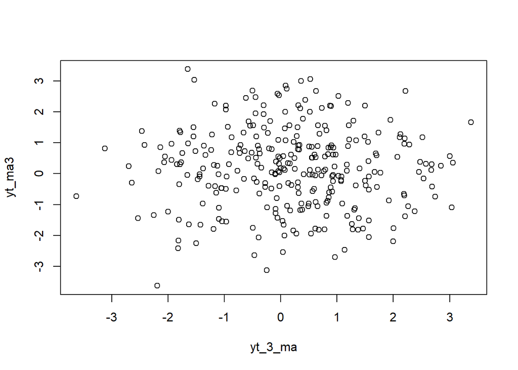

```r
plot(y=yt_ma3, x=yt_3_ma)
```

```r
cor(yt_ma3, yt_3_ma)
```

```
## [1] -0.008234312
```

Berdasarkan scatterplot tersebut, terlihat bahwa cenderung tidak terdapat hubungan antara $Y_t$ dengan $Y_{t-3}$

# Proses AR(2)

## Pembangkitan AR(2) secara Manual

```r
set.seed(2406)

n<-length(wn)
n
```

```
## [1] 300
```

```r
ar <- c()
ar[1] <- wn[1]
ar[2] <- wn[2] + 0.5 * ar[1]

for (i in 3:n) {
  ar[i] <- wn[i] + 0.5 * ar[i-1] + 0.2 * ar[i-2]
}
ar
```

```
##   [1]  0.065452712 -2.125142761 -1.183064394 -1.666089966  0.126835042
##   [6] -0.449398105 -2.078314259 -1.033069210 -0.982984731  0.033157734
##  [11] -0.354212143 -1.159000120 -0.075976182  1.168523453  2.102509057
##  [16]  1.272887338 -0.066799790  0.734257800 -0.954759467  0.700157447
##  [21]  0.699128112  0.996796919  1.511995596  0.627114109  1.296224646
##  [26]  0.869252906  1.025714231  0.247697625 -0.881905111 -1.443176466
##  [31] -2.870817422 -2.099415077 -0.629183737 -0.092814058  0.361887499
##  [36] -0.245620832 -1.147671981 -1.379681755 -0.328424503  1.287863926
##  [41] -0.563548647  0.051628515  0.182405011 -0.051319852  0.800208440
##  [46]  0.952544806  0.119998509 -0.323738937  1.953083975  1.039914585
##  [51]  1.554233987  1.678700657  1.010225357  2.217662449  3.360609249
##  [56]  3.534875392  1.967846702  2.212626844  1.924824962 -0.202045134
##  [61]  0.958668820 -0.049770105  0.205301750  1.590402868  0.494220572
##  [66]  0.303846455  1.658018341 -1.453295379 -1.271157206 -0.141674111
##  [71]  0.327327188  1.606946703  1.961809162  2.365032832  1.632262067
```

[output cut: 45 more lines]

## Pembangkitan AR(2) dengan arima.sim

```r
ar2 <- arima.sim(list(order = c(2,0,0), ar = c(0.5, 0.2)), n = 300)
ar2
```

[output not shown]

[output cut: 49 more lines]

## Karakteristik AR(2)

### Plot Time Series

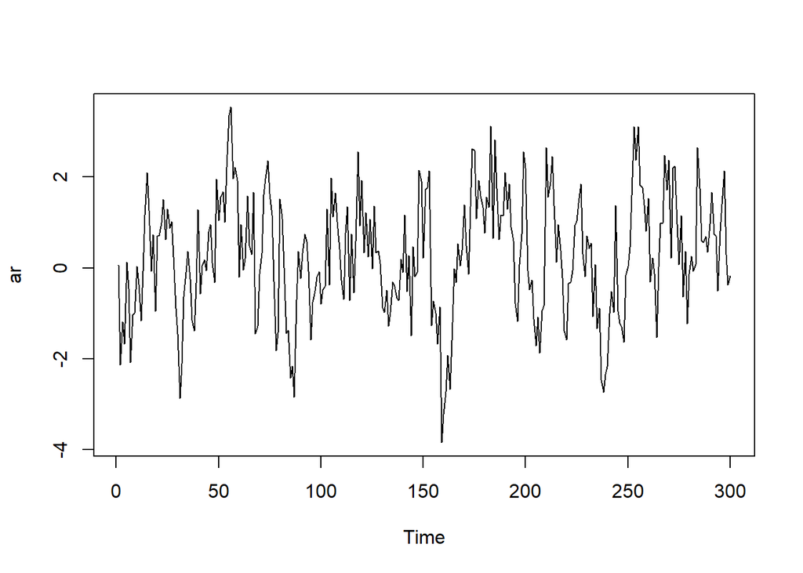

```r
ts.plot(ar)
```

Berdasarkan plot time series tersebut terlihat bahwa data cenderung stasioner pada rataan

### Plot ACF

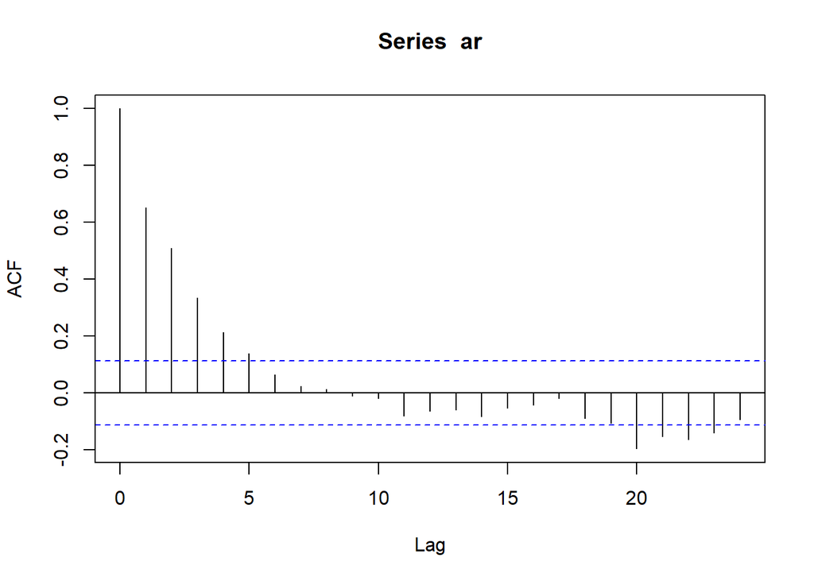

```r
acf(ar)
```

Berdasarkan plot ACF tersebut terlihat bahwa plot ACF cenderung tails off dan cenderung membentuk pola grafik sinus

### Plot PACF

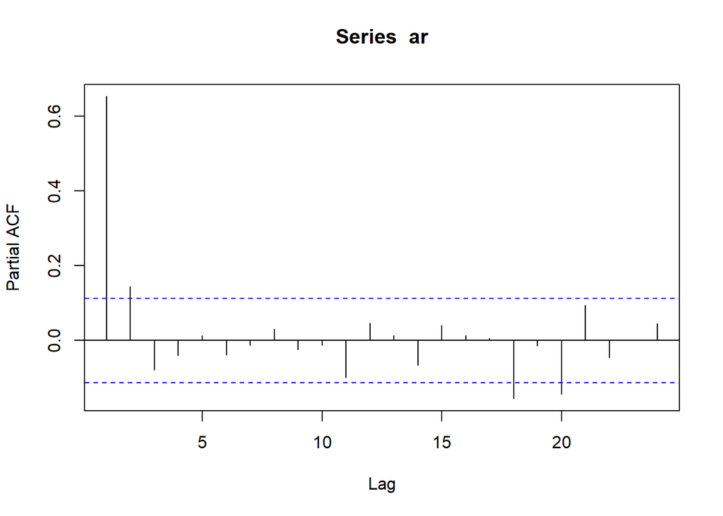

```r
pacf(ar)
```

Berdasarkan plot PACF tersebut, terlihat bahwa plot PACF cuts off pada lag kedua, sejalan dengan teori yang ada

### Plot EACF

```r
TSA::eacf(ar)
```

```
## AR/MA
##   0 1 2 3 4 5 6 7 8 9 10 11 12 13
## 0 x x x x x o o o o o o  o  o  o
## 1 x x o o o o o o o o o  o  o  o
## 2 x x o o o o o o o o o  o  o  o
## 3 x x o o o o o o o o o  o  o  o
## 4 x x x o o o o o o o o  o  o  o
## 5 x x x o o o o o o o o  o  o  o
## 6 x x x o o o o o o o o  o  o  o
## 7 x x x o o o o o o o o  o  o  o
```

## Scatterplot Antar Lag

### Korelasi antara $Y_t$ dengan $Y_{t-1}$

```r
#Yt
yt_ar <- ar[-1]
yt_ar
```

```
##   [1] -2.125142761 -1.183064394 -1.666089966  0.126835042 -0.449398105
##   [6] -2.078314259 -1.033069210 -0.982984731  0.033157734 -0.354212143
##  [11] -1.159000120 -0.075976182  1.168523453  2.102509057  1.272887338
##  [16] -0.066799790  0.734257800 -0.954759467  0.700157447  0.699128112
##  [21]  0.996796919  1.511995596  0.627114109  1.296224646  0.869252906
##  [26]  1.025714231  0.247697625 -0.881905111 -1.443176466 -2.870817422
##  [31] -2.099415077 -0.629183737 -0.092814058  0.361887499 -0.245620832
##  [36] -1.147671981 -1.379681755 -0.328424503  1.287863926 -0.563548647
##  [41]  0.051628515  0.182405011 -0.051319852  0.800208440  0.952544806
##  [46]  0.119998509 -0.323738937  1.953083975  1.039914585  1.554233987
##  [51]  1.678700657  1.010225357  2.217662449  3.360609249  3.534875392
##  [56]  1.967846702  2.212626844  1.924824962 -0.202045134  0.958668820
##  [61] -0.049770105  0.205301750  1.590402868  0.494220572  0.303846455
##  [66]  1.658018341 -1.453295379 -1.271157206 -0.141674111  0.327327188
##  [71]  1.606946703  1.961809162  2.365032832  1.632262067  1.169655728
```

[output cut: 45 more lines]

```r
#Yt-1
yt_1_ar <- ar[-300]
yt_1_ar
```

```
##   [1]  0.065452712 -2.125142761 -1.183064394 -1.666089966  0.126835042
##   [6] -0.449398105 -2.078314259 -1.033069210 -0.982984731  0.033157734
##  [11] -0.354212143 -1.159000120 -0.075976182  1.168523453  2.102509057
##  [16]  1.272887338 -0.066799790  0.734257800 -0.954759467  0.700157447
##  [21]  0.699128112  0.996796919  1.511995596  0.627114109  1.296224646
##  [26]  0.869252906  1.025714231  0.247697625 -0.881905111 -1.443176466
##  [31] -2.870817422 -2.099415077 -0.629183737 -0.092814058  0.361887499
##  [36] -0.245620832 -1.147671981 -1.379681755 -0.328424503  1.287863926
##  [41] -0.563548647  0.051628515  0.182405011 -0.051319852  0.800208440
##  [46]  0.952544806  0.119998509 -0.323738937  1.953083975  1.039914585
##  [51]  1.554233987  1.678700657  1.010225357  2.217662449  3.360609249
##  [56]  3.534875392  1.967846702  2.212626844  1.924824962 -0.202045134
##  [61]  0.958668820 -0.049770105  0.205301750  1.590402868  0.494220572
##  [66]  0.303846455  1.658018341 -1.453295379 -1.271157206 -0.141674111
##  [71]  0.327327188  1.606946703  1.961809162  2.365032832  1.632262067
```

[output cut: 45 more lines]

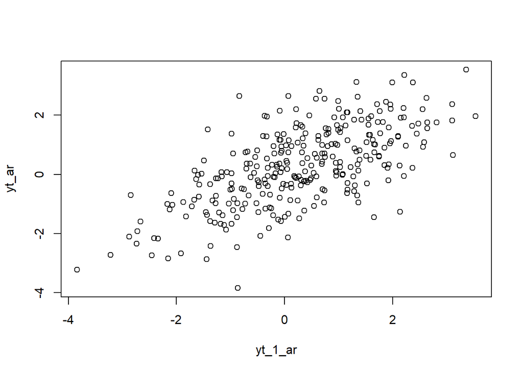

```r
plot(y=yt_ar, x=yt_1_ar)
```

```r
cor(yt_ar, yt_1_ar)
```

```
## [1] 0.6529007
```

Korelasi antara $Y_t$ dengan $Y_{t-1}$ dari hasil simulasi mendekati perhitungan teoritis, yaitu:
$$\rho_1 =
\frac{\phi_1}{1 - \phi_2} = \frac{0.5}{1 - 0.2} = 0.625$$

### Korelasi antara $Y_t$ dengan $Y_{t-2}$

```r
#Yt
yt_ar2 <- ar[-c(1,2)]
yt_ar2
```

```
##   [1] -1.183064394 -1.666089966  0.126835042 -0.449398105 -2.078314259
##   [6] -1.033069210 -0.982984731  0.033157734 -0.354212143 -1.159000120
##  [11] -0.075976182  1.168523453  2.102509057  1.272887338 -0.066799790
##  [16]  0.734257800 -0.954759467  0.700157447  0.699128112  0.996796919
##  [21]  1.511995596  0.627114109  1.296224646  0.869252906  1.025714231
##  [26]  0.247697625 -0.881905111 -1.443176466 -2.870817422 -2.099415077
##  [31] -0.629183737 -0.092814058  0.361887499 -0.245620832 -1.147671981
##  [36] -1.379681755 -0.328424503  1.287863926 -0.563548647  0.051628515
##  [41]  0.182405011 -0.051319852  0.800208440  0.952544806  0.119998509
##  [46] -0.323738937  1.953083975  1.039914585  1.554233987  1.678700657
##  [51]  1.010225357  2.217662449  3.360609249  3.534875392  1.967846702
##  [56]  2.212626844  1.924824962 -0.202045134  0.958668820 -0.049770105
##  [61]  0.205301750  1.590402868  0.494220572  0.303846455  1.658018341
##  [66] -1.453295379 -1.271157206 -0.141674111  0.327327188  1.606946703
##  [71]  1.961809162  2.365032832  1.632262067  1.169655728 -0.291094788
```

[output cut: 45 more lines]

```r
#Yt-2
yt_2_ar <- ar[-c(299,300)]
yt_2_ar
```

```
##   [1]  0.065452712 -2.125142761 -1.183064394 -1.666089966  0.126835042
##   [6] -0.449398105 -2.078314259 -1.033069210 -0.982984731  0.033157734
##  [11] -0.354212143 -1.159000120 -0.075976182  1.168523453  2.102509057
##  [16]  1.272887338 -0.066799790  0.734257800 -0.954759467  0.700157447
##  [21]  0.699128112  0.996796919  1.511995596  0.627114109  1.296224646
##  [26]  0.869252906  1.025714231  0.247697625 -0.881905111 -1.443176466
##  [31] -2.870817422 -2.099415077 -0.629183737 -0.092814058  0.361887499
##  [36] -0.245620832 -1.147671981 -1.379681755 -0.328424503  1.287863926
##  [41] -0.563548647  0.051628515  0.182405011 -0.051319852  0.800208440
##  [46]  0.952544806  0.119998509 -0.323738937  1.953083975  1.039914585
##  [51]  1.554233987  1.678700657  1.010225357  2.217662449  3.360609249
##  [56]  3.534875392  1.967846702  2.212626844  1.924824962 -0.202045134
##  [61]  0.958668820 -0.049770105  0.205301750  1.590402868  0.494220572
##  [66]  0.303846455  1.658018341 -1.453295379 -1.271157206 -0.141674111
##  [71]  0.327327188  1.606946703  1.961809162  2.365032832  1.632262067
```

[output cut: 45 more lines]

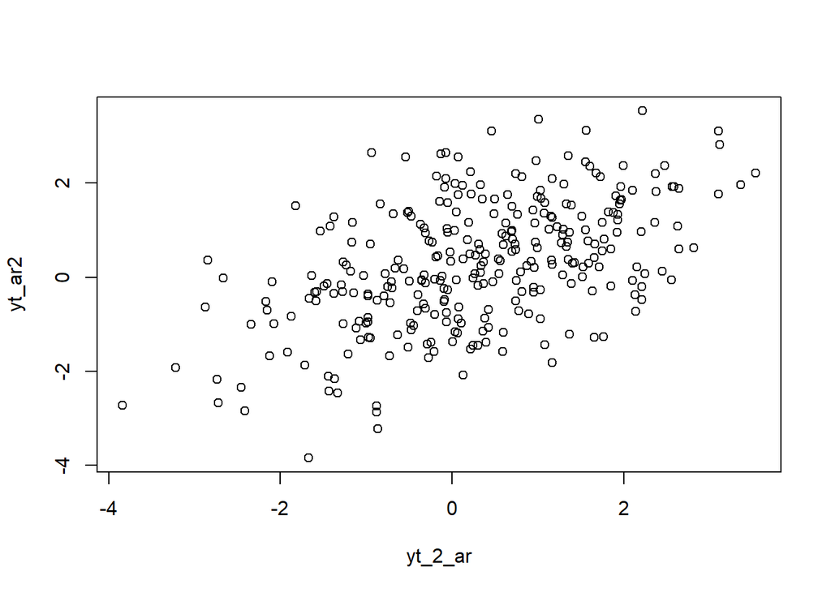

```r
plot(y=yt_ar2, x=yt_2_ar)
```

```r
cor(yt_ar2, yt_2_ar)
```

```
## [1] 0.5119773
```

Korelasi antara $Y_t$ dengan $Y_{t-2}$ dari hasil simulasi mendekati perhitungan teoritis, yaitu:
$$\rho_2 =
\phi_1\rho_1 + \phi_2 = 0.5(0.625) + 0.2 = 0.5125$$

### Korelasi antara $Y_t$ dengan $Y_{t-3}$

```r
#Yt
yt_ar3 <- ar[-c(1,2,3)]
yt_ar3
```

```
##   [1] -1.666089966  0.126835042 -0.449398105 -2.078314259 -1.033069210
##   [6] -0.982984731  0.033157734 -0.354212143 -1.159000120 -0.075976182
##  [11]  1.168523453  2.102509057  1.272887338 -0.066799790  0.734257800
##  [16] -0.954759467  0.700157447  0.699128112  0.996796919  1.511995596
##  [21]  0.627114109  1.296224646  0.869252906  1.025714231  0.247697625
##  [26] -0.881905111 -1.443176466 -2.870817422 -2.099415077 -0.629183737
##  [31] -0.092814058  0.361887499 -0.245620832 -1.147671981 -1.379681755
##  [36] -0.328424503  1.287863926 -0.563548647  0.051628515  0.182405011
##  [41] -0.051319852  0.800208440  0.952544806  0.119998509 -0.323738937
##  [46]  1.953083975  1.039914585  1.554233987  1.678700657  1.010225357
##  [51]  2.217662449  3.360609249  3.534875392  1.967846702  2.212626844
##  [56]  1.924824962 -0.202045134  0.958668820 -0.049770105  0.205301750
##  [61]  1.590402868  0.494220572  0.303846455  1.658018341 -1.453295379
##  [66] -1.271157206 -0.141674111  0.327327188  1.606946703  1.961809162
##  [71]  2.365032832  1.632262067  1.169655728 -0.291094788 -1.819521812
```

[output cut: 45 more lines]

```r
#Yt-3
yt_3_ar <- ar[-c(298,299,300)]
yt_3_ar
```

```
##   [1]  0.065452712 -2.125142761 -1.183064394 -1.666089966  0.126835042
##   [6] -0.449398105 -2.078314259 -1.033069210 -0.982984731  0.033157734
##  [11] -0.354212143 -1.159000120 -0.075976182  1.168523453  2.102509057
##  [16]  1.272887338 -0.066799790  0.734257800 -0.954759467  0.700157447
##  [21]  0.699128112  0.996796919  1.511995596  0.627114109  1.296224646
##  [26]  0.869252906  1.025714231  0.247697625 -0.881905111 -1.443176466
##  [31] -2.870817422 -2.099415077 -0.629183737 -0.092814058  0.361887499
##  [36] -0.245620832 -1.147671981 -1.379681755 -0.328424503  1.287863926
##  [41] -0.563548647  0.051628515  0.182405011 -0.051319852  0.800208440
##  [46]  0.952544806  0.119998509 -0.323738937  1.953083975  1.039914585
##  [51]  1.554233987  1.678700657  1.010225357  2.217662449  3.360609249
##  [56]  3.534875392  1.967846702  2.212626844  1.924824962 -0.202045134
##  [61]  0.958668820 -0.049770105  0.205301750  1.590402868  0.494220572
##  [66]  0.303846455  1.658018341 -1.453295379 -1.271157206 -0.141674111
##  [71]  0.327327188  1.606946703  1.961809162  2.365032832  1.632262067
```

[output cut: 45 more lines]

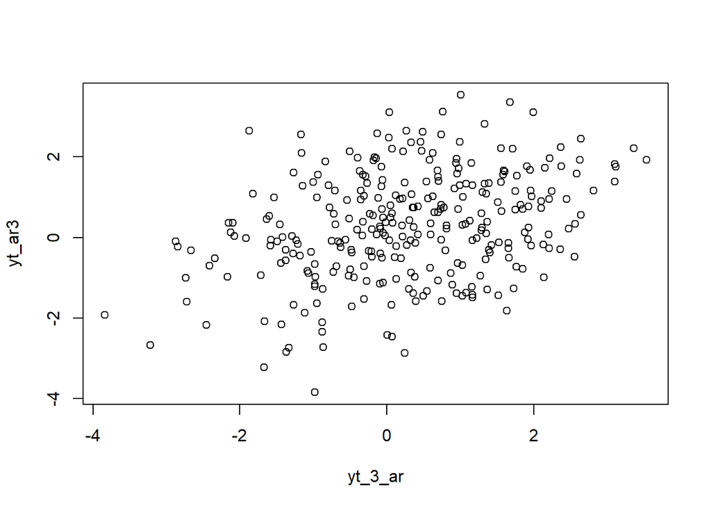

```r
plot(y=yt_ar3, x=yt_3_ar)
```

```r
cor(yt_ar3, yt_3_ar)
```

```
## [1] 0.3368928
```

Korelasi antara $Y_t$ dengan $Y_{t-3}$ dari hasil simulasi mendekati perhitungan teoritis, yaitu:
$$\rho_3 =
\phi_1\rho_2 + \phi_2\rho_1 = 0.5(0.5125) + 0.2(0.625) = 0.25625 + 0.125
= 0.38125$$

# Proses ARMA(2,2)

## Pembangkitan ARMA(2,2) secara Manual

```r
set.seed(2406)
wn <- rnorm(300)
n = length(wn)
phi1 = 0.5
phi2 = 0.2
theta1 = 0.4
theta2 = 0.6

y.arma = c()
y.arma[1] = wn[1]
y.arma[2] = wn[2] + phi1*y.arma[1] + theta1*wn[1]

for (i in 3:n){
  y.arma[i] = phi1*y.arma[i-1] + phi2*y.arma[i-2] + theta1*wn[i-1] + theta2*wn[i-2] + wn[i]
}
y.arma
```

```
##   [1]  0.0654527118 -2.0989616758 -1.9938498709 -3.4144013803 -1.2494395804
##   [6] -1.3983180681 -2.1819724760 -2.1340337767 -2.6432009709 -0.9798776841
##  [11] -0.9307398884 -1.2807903363 -0.7521035158  0.4427329081  2.5243327288
##  [16]  2.8150050328  1.7038605794  1.4712702866 -0.7011362215  0.7588083399
##  [21]  0.4063354102  1.6965426314  2.3301912308  1.8299904989  2.4542676472
##  [26]  1.7640112298  2.1511501808  1.1795350613 -0.1673975225 -1.6473199353
##  [31] -3.9772310755 -4.1136479253 -3.1914402213 -1.6041365991 -0.0527483667
##  [36] -0.1565542675 -1.0287878144 -1.9861230466 -1.5689003935  0.3286850719
##  [41] -0.2454577780  0.5989274116 -0.1350727708  0.0526192609  0.8891235059
##  [46]  1.2418362710  0.9811414954  0.2957873508  1.8955875055  1.6269048128
##  [51]  3.1420502055  2.9243430029  2.6142460117  3.6289729858  4.8538094425
##  [56]  6.2097165610  5.3981624083  5.1206907596  3.9905837209  1.8954609568
##  [61]  2.0327457433  0.2124703419  0.7605949992  1.6426615050  1.2535627692
##  [66]  1.4557764054  2.0760892662 -0.6077801697 -0.8576643535 -1.5221142207
##  [71] -0.4920367797  1.6528731121  2.8009841563  4.1139245189  3.7553606975
```

[output cut: 45 more lines]

## Pembangkitan ARMA(2,2) dengan arima.sim

```r
arma22 <- arima.sim(list(order = c(2,0,2), ar = c(0.5, 0.2), ma = c(0.4, 0.6)), n = 300)
arma22
```

```
## Time Series:
## Start = 1
## End = 300
## Frequency = 1
##   [1]  1.30154264  1.80114941  2.58992239  2.57767943  3.70061857  3.50251044
##   [7]  3.95989299  3.07902761  1.90814234  2.01829257  0.57807913  0.55188481
##  [13]  0.54200671  0.45139731  1.21422695  1.21775986  1.22713971  0.25317362
##  [19]  0.95304667  0.67548224  0.71958636  0.22648134  0.32627111  0.54888050
##  [25]  0.50664947  0.90147830  0.51161798  0.43687072  0.47779288  0.18163513
##  [31]  0.60028581  0.03912742  0.27627084  1.19294128  1.22298915  1.19902322
##  [37]  0.91815166  1.08446651 -0.87106860 -2.61373052 -4.95746243 -4.42048611
##  [43] -3.14416569 -3.03963557 -2.70263323 -4.09159438 -2.22591537 -2.41814566
##  [49] -1.38622231 -2.63245589 -1.58044502 -1.16531334 -3.14611774 -2.17085648
##  [55] -3.50594393 -3.46500254 -2.44409173 -0.76683136  0.17498971  0.94531113
##  [61]  0.76480247  1.05246484  1.13042098  1.75127412  1.90677847  4.19880898
```

[output cut: 39 more lines]

## Karakteristik ARMA(2,2)

### Time Series

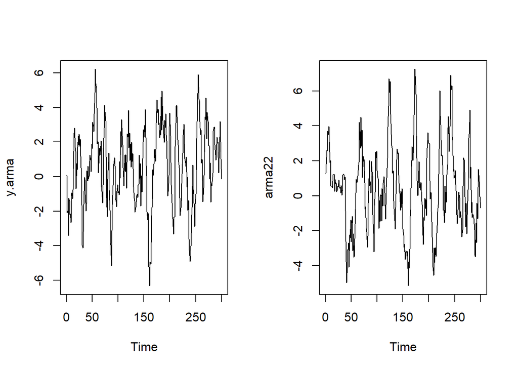

```r
par(mfrow = c(1, 2))
ts.plot(y.arma)
ts.plot(arma22)
```

```r
par(mfrow = c(1, 1))
```

Berdasarkan plot time series tersebut, terlihat bahwa model ARMA(2,2) cenderung stasioner dalam rataan

### Plot ACF

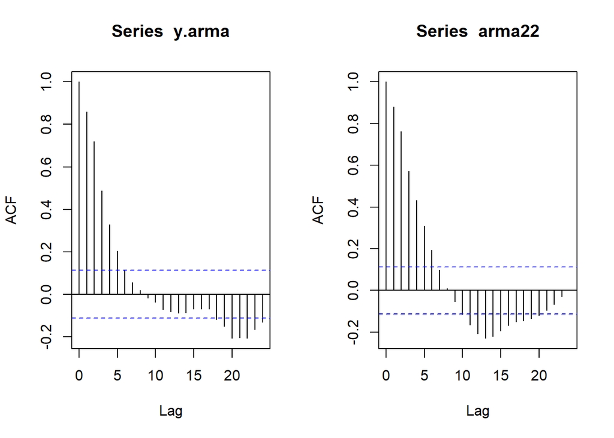

```r
par(mfrow = c(1, 2))
acf(y.arma)
acf(arma22)
```

```r
par(mfrow = c(1, 1))
```

Berdasarkan plot ACF tersebut, terlihat bahwa model ARMA(2,2) hasil simulasi memiliki plot ACF yang tails off, sesuai dengan teori yang ada

### Plot PACF

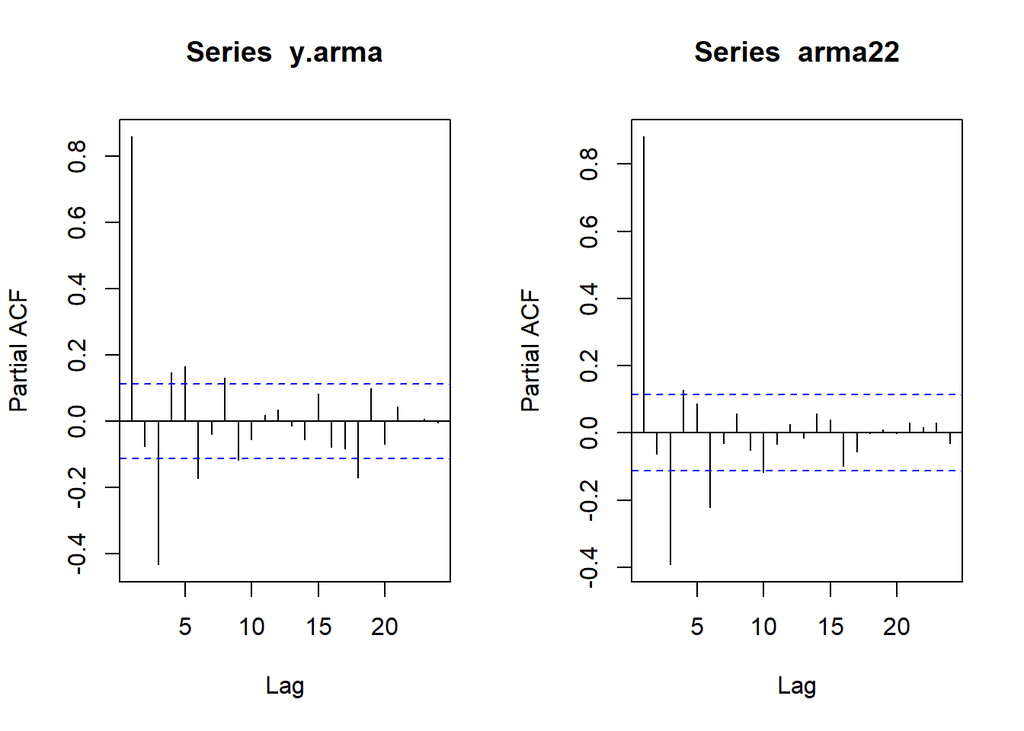

```r
par(mfrow = c(1, 2))
pacf(y.arma)
pacf(arma22)
```

```r
par(mfrow = c(1, 1))
```

Berdasarkan plot PACF tersebut, terlihat bahwa model ARMA(2,2) hasil simulasi memiliki plot PACF yang tails off, sesuai dengan teori

### Plot EACF

```r
TSA::eacf(y.arma)
```

```
## AR/MA
##   0 1 2 3 4 5 6 7 8 9 10 11 12 13
## 0 x x x x x o o o o o o  o  o  o
## 1 o x o o o o o o o o o  o  o  o
## 2 x x o o o o o o o o o  o  o  o
## 3 x x x o o o o o o o o  o  o  o
## 4 x x x o o o o o o o o  o  o  o
## 5 x x x o o x o o o o o  o  o  o
## 6 x x o o o x o o o o o  o  o  o
## 7 x x x x x o x o o o o  o  o  o
```

```r
TSA::eacf(arma22)
```

```
## AR/MA
##   0 1 2 3 4 5 6 7 8 9 10 11 12 13
## 0 x x x x x x o o o o x  x  x  x
## 1 o x o o x o o o o o o  o  x  o
## 2 x x o o o o o o o o o  o  o  o
## 3 x x x x x o o o o o o  o  o  o
## 4 x x x x x o o o o o o  o  o  o
## 5 x x x x o o o o o o o  o  o  o
## 6 x x x x o x o o o o o  o  o  o
## 7 x o x x x x o x o o o  o  o  o
```

Berdasarkan pola segitiga nol pada plot EACF, terlihat bahwa segitiga nol berada pada ordo AR(2) dan ordo MA(2)

## Scatterplot Antar Lag

### Korelasi antara $Y_t$ dengan $Y_{t-1}$

```r
#Yt
yt_arma <- arma22[-1]
yt_arma
```

```
##   [1]  1.80114941  2.58992239  2.57767943  3.70061857  3.50251044  3.95989299
##   [7]  3.07902761  1.90814234  2.01829257  0.57807913  0.55188481  0.54200671
##  [13]  0.45139731  1.21422695  1.21775986  1.22713971  0.25317362  0.95304667
##  [19]  0.67548224  0.71958636  0.22648134  0.32627111  0.54888050  0.50664947
##  [25]  0.90147830  0.51161798  0.43687072  0.47779288  0.18163513  0.60028581
##  [31]  0.03912742  0.27627084  1.19294128  1.22298915  1.19902322  0.91815166
##  [37]  1.08446651 -0.87106860 -2.61373052 -4.95746243 -4.42048611 -3.14416569
##  [43] -3.03963557 -2.70263323 -4.09159438 -2.22591537 -2.41814566 -1.38622231
##  [49] -2.63245589 -1.58044502 -1.16531334 -3.14611774 -2.17085648 -3.50594393
##  [55] -3.46500254 -2.44409173 -0.76683136  0.17498971  0.94531113  0.76480247
##  [61]  1.05246484  1.13042098  1.75127412  1.90677847  4.19880898  3.18737861
##  [67]  2.72983353  4.48835018  2.83364238  3.76769192  1.04433807  2.26369824
##  [73]  1.96861718  2.08774146  0.73790345 -0.75973675 -0.63228368 -1.85664991
##  [79] -2.05318090 -2.94903040 -2.29411732 -0.41702840  0.99694126  2.02722098
##  [85]  0.59227636  0.81483034  0.17381833  1.97696362  1.39349433  1.13656013
```

[output cut: 35 more lines]

```r
#Yt-1
yt_1_arma <- arma22[-300]
yt_1_arma
```

```
##   [1]  1.30154264  1.80114941  2.58992239  2.57767943  3.70061857  3.50251044
##   [7]  3.95989299  3.07902761  1.90814234  2.01829257  0.57807913  0.55188481
##  [13]  0.54200671  0.45139731  1.21422695  1.21775986  1.22713971  0.25317362
##  [19]  0.95304667  0.67548224  0.71958636  0.22648134  0.32627111  0.54888050
##  [25]  0.50664947  0.90147830  0.51161798  0.43687072  0.47779288  0.18163513
##  [31]  0.60028581  0.03912742  0.27627084  1.19294128  1.22298915  1.19902322
##  [37]  0.91815166  1.08446651 -0.87106860 -2.61373052 -4.95746243 -4.42048611
##  [43] -3.14416569 -3.03963557 -2.70263323 -4.09159438 -2.22591537 -2.41814566
##  [49] -1.38622231 -2.63245589 -1.58044502 -1.16531334 -3.14611774 -2.17085648
##  [55] -3.50594393 -3.46500254 -2.44409173 -0.76683136  0.17498971  0.94531113
##  [61]  0.76480247  1.05246484  1.13042098  1.75127412  1.90677847  4.19880898
##  [67]  3.18737861  2.72983353  4.48835018  2.83364238  3.76769192  1.04433807
##  [73]  2.26369824  1.96861718  2.08774146  0.73790345 -0.75973675 -0.63228368
##  [79] -1.85664991 -2.05318090 -2.94903040 -2.29411732 -0.41702840  0.99694126
##  [85]  2.02722098  0.59227636  0.81483034  0.17381833  1.97696362  1.39349433
```

[output cut: 35 more lines]

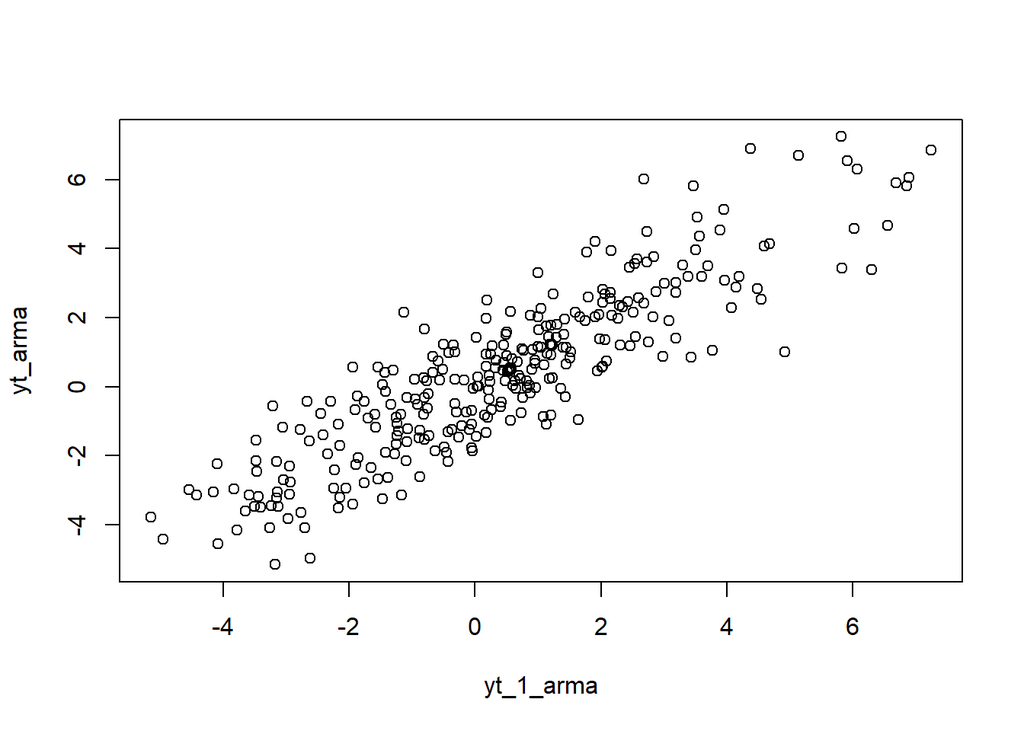

```r
plot(y=yt_arma, x=yt_1_arma)
```

```r
cor(yt_arma, yt_1_arma)
```

```
## [1] 0.881789
```

Korelasi antara $Y_t$ dengan $Y_{t-1}$ dari hasil simulasi mendekati perhitungan teoritis.

$$\psi_1 = \phi_1 + \theta_1 = 0.5 + 0.4 =
0.9$$

$$\psi_2 = \phi_1\psi_1 + \phi_2 +
\theta_2 = 0.5(0.9) + 0.2 + 0.6 = 1.25$$

$$\gamma_0 = \phi_1\gamma_1 +
\phi_2\gamma_2 + \sigma^2(1 + \theta_1\psi_1 +
\theta_2\psi_2)$$

$$\gamma_1 = \phi_1\gamma_0 +
\phi_2\gamma_1 + \sigma^2(\theta_1 + \theta_2\psi_1)$$

$$\gamma_2 = \phi_1\gamma_1 +
\phi_2\gamma_0 + \sigma^2\theta_2$$

$$\gamma_0 = 5.0171, \gamma_1 = 4.3107,
\gamma_2 = 3.7588$$

$$\rho_1 = \frac{\gamma_1}{\gamma_0} =
\frac{4.3107}{5.0171} = 0.8592$$

### Korelasi antara $Y_t$ dengan $Y_{t-2}$

```r
#Yt
yt_arma2 <- arma22[-c(1,2)]
yt_arma2
```

```
##   [1]  2.58992239  2.57767943  3.70061857  3.50251044  3.95989299  3.07902761
##   [7]  1.90814234  2.01829257  0.57807913  0.55188481  0.54200671  0.45139731
##  [13]  1.21422695  1.21775986  1.22713971  0.25317362  0.95304667  0.67548224
##  [19]  0.71958636  0.22648134  0.32627111  0.54888050  0.50664947  0.90147830
##  [25]  0.51161798  0.43687072  0.47779288  0.18163513  0.60028581  0.03912742
##  [31]  0.27627084  1.19294128  1.22298915  1.19902322  0.91815166  1.08446651
##  [37] -0.87106860 -2.61373052 -4.95746243 -4.42048611 -3.14416569 -3.03963557
##  [43] -2.70263323 -4.09159438 -2.22591537 -2.41814566 -1.38622231 -2.63245589
##  [49] -1.58044502 -1.16531334 -3.14611774 -2.17085648 -3.50594393 -3.46500254
##  [55] -2.44409173 -0.76683136  0.17498971  0.94531113  0.76480247  1.05246484
##  [61]  1.13042098  1.75127412  1.90677847  4.19880898  3.18737861  2.72983353
##  [67]  4.48835018  2.83364238  3.76769192  1.04433807  2.26369824  1.96861718
##  [73]  2.08774146  0.73790345 -0.75973675 -0.63228368 -1.85664991 -2.05318090
##  [79] -2.94903040 -2.29411732 -0.41702840  0.99694126  2.02722098  0.59227636
##  [85]  0.81483034  0.17381833  1.97696362  1.39349433  1.13656013 -1.08845726
```

[output cut: 35 more lines]

```r
#Yt-2
yt_2_arma <- arma22[-c(299,300)]
yt_2_arma
```

```
##   [1]  1.30154264  1.80114941  2.58992239  2.57767943  3.70061857  3.50251044
##   [7]  3.95989299  3.07902761  1.90814234  2.01829257  0.57807913  0.55188481
##  [13]  0.54200671  0.45139731  1.21422695  1.21775986  1.22713971  0.25317362
##  [19]  0.95304667  0.67548224  0.71958636  0.22648134  0.32627111  0.54888050
##  [25]  0.50664947  0.90147830  0.51161798  0.43687072  0.47779288  0.18163513
##  [31]  0.60028581  0.03912742  0.27627084  1.19294128  1.22298915  1.19902322
##  [37]  0.91815166  1.08446651 -0.87106860 -2.61373052 -4.95746243 -4.42048611
##  [43] -3.14416569 -3.03963557 -2.70263323 -4.09159438 -2.22591537 -2.41814566
##  [49] -1.38622231 -2.63245589 -1.58044502 -1.16531334 -3.14611774 -2.17085648
##  [55] -3.50594393 -3.46500254 -2.44409173 -0.76683136  0.17498971  0.94531113
##  [61]  0.76480247  1.05246484  1.13042098  1.75127412  1.90677847  4.19880898
##  [67]  3.18737861  2.72983353  4.48835018  2.83364238  3.76769192  1.04433807
##  [73]  2.26369824  1.96861718  2.08774146  0.73790345 -0.75973675 -0.63228368
##  [79] -1.85664991 -2.05318090 -2.94903040 -2.29411732 -0.41702840  0.99694126
##  [85]  2.02722098  0.59227636  0.81483034  0.17381833  1.97696362  1.39349433
```

[output cut: 35 more lines]

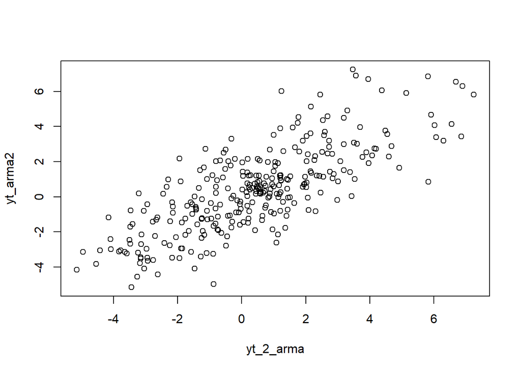

```r
plot(y=yt_arma2, x=yt_2_arma)
```

```r
cor(yt_arma2, yt_2_arma)
```

```
## [1] 0.7637246
```

Korelasi antara $Y_t$ dengan $Y_{t-2}$ dari hasil simulasi mendekati perhitungan teoritis.

$$\rho_2 = \frac{\gamma_2}{\gamma_0} =
\frac{3.7588}{5.0171} = 0.7492$$

### Korelasi antara $Y_t$ dengan $Y_{t-3}$

```r
#Yt
yt_arma3 <- arma22[-c(1,2,3)]
yt_arma3
```

```
##   [1]  2.57767943  3.70061857  3.50251044  3.95989299  3.07902761  1.90814234
##   [7]  2.01829257  0.57807913  0.55188481  0.54200671  0.45139731  1.21422695
##  [13]  1.21775986  1.22713971  0.25317362  0.95304667  0.67548224  0.71958636
##  [19]  0.22648134  0.32627111  0.54888050  0.50664947  0.90147830  0.51161798
##  [25]  0.43687072  0.47779288  0.18163513  0.60028581  0.03912742  0.27627084
##  [31]  1.19294128  1.22298915  1.19902322  0.91815166  1.08446651 -0.87106860
##  [37] -2.61373052 -4.95746243 -4.42048611 -3.14416569 -3.03963557 -2.70263323
##  [43] -4.09159438 -2.22591537 -2.41814566 -1.38622231 -2.63245589 -1.58044502
##  [49] -1.16531334 -3.14611774 -2.17085648 -3.50594393 -3.46500254 -2.44409173
##  [55] -0.76683136  0.17498971  0.94531113  0.76480247  1.05246484  1.13042098
##  [61]  1.75127412  1.90677847  4.19880898  3.18737861  2.72983353  4.48835018
##  [67]  2.83364238  3.76769192  1.04433807  2.26369824  1.96861718  2.08774146
##  [73]  0.73790345 -0.75973675 -0.63228368 -1.85664991 -2.05318090 -2.94903040
##  [79] -2.29411732 -0.41702840  0.99694126  2.02722098  0.59227636  0.81483034
##  [85]  0.17381833  1.97696362  1.39349433  1.13656013 -1.08845726 -2.14252133
```

[output cut: 35 more lines]

```r
#Yt-3
yt_3_arma <- arma22[-c(298,299,300)]
yt_3_arma
```

```
##   [1]  1.30154264  1.80114941  2.58992239  2.57767943  3.70061857  3.50251044
##   [7]  3.95989299  3.07902761  1.90814234  2.01829257  0.57807913  0.55188481
##  [13]  0.54200671  0.45139731  1.21422695  1.21775986  1.22713971  0.25317362
##  [19]  0.95304667  0.67548224  0.71958636  0.22648134  0.32627111  0.54888050
##  [25]  0.50664947  0.90147830  0.51161798  0.43687072  0.47779288  0.18163513
##  [31]  0.60028581  0.03912742  0.27627084  1.19294128  1.22298915  1.19902322
##  [37]  0.91815166  1.08446651 -0.87106860 -2.61373052 -4.95746243 -4.42048611
##  [43] -3.14416569 -3.03963557 -2.70263323 -4.09159438 -2.22591537 -2.41814566
##  [49] -1.38622231 -2.63245589 -1.58044502 -1.16531334 -3.14611774 -2.17085648
##  [55] -3.50594393 -3.46500254 -2.44409173 -0.76683136  0.17498971  0.94531113
##  [61]  0.76480247  1.05246484  1.13042098  1.75127412  1.90677847  4.19880898
##  [67]  3.18737861  2.72983353  4.48835018  2.83364238  3.76769192  1.04433807
##  [73]  2.26369824  1.96861718  2.08774146  0.73790345 -0.75973675 -0.63228368
##  [79] -1.85664991 -2.05318090 -2.94903040 -2.29411732 -0.41702840  0.99694126
##  [85]  2.02722098  0.59227636  0.81483034  0.17381833  1.97696362  1.39349433
```

[output cut: 35 more lines]

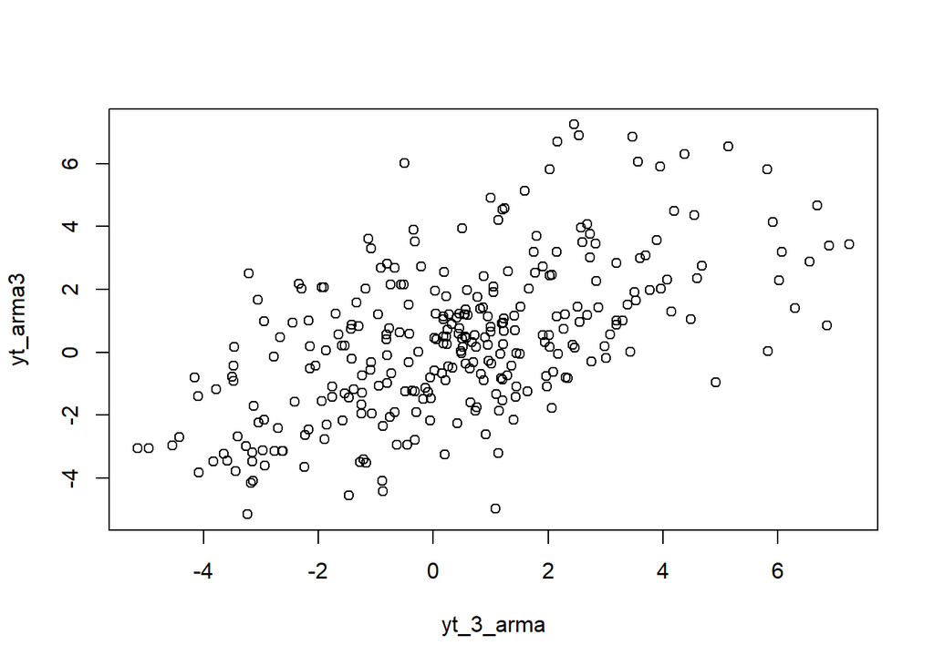

```r
plot(y=yt_arma3, x=yt_3_arma)
```

```r
cor(yt_arma3, yt_3_arma)
```

```
## [1] 0.5736443
```

Korelasi antara $Y_t$ dengan $Y_{t-3}$ dari hasil simulasi mendekati perhitungan teoritis.

$$\rho_k = \phi_1\rho_{k-1} +
\phi_2\rho_{k-2} \quad \text{untuk } k \ge 3$$

$$\rho_3 = 0.5(0.7492) + 0.2(0.8592) =
0.3746 + 0.1718 = 0.5464$$